# SCC.212 Week 4 Task

# Week 4: Bomb Sweeper

This exercise focusses upon testing and strengthening your understanding of inheritance, object references and implementing recursive algorithms. **The aim is for you to gain experience of writing more algorithmically complex code in Java while maintaining code elegance through using a combination of iteration and recursion.**

# The Task

Your task this week is to implement the logic behind the well-known game of *minesweeper*. The graphical functionality has been provided for you, as has a template for a (reasonably!) elegant object model. For this task, you should *only* need to modify the **BombSquare** class, which provides a basic template for the exercise.

**You are not permitted to modify the GameBoard or GameSquare classes. Restrict your work to the BombSquare class, and/or any other new classes you may wish to create.**

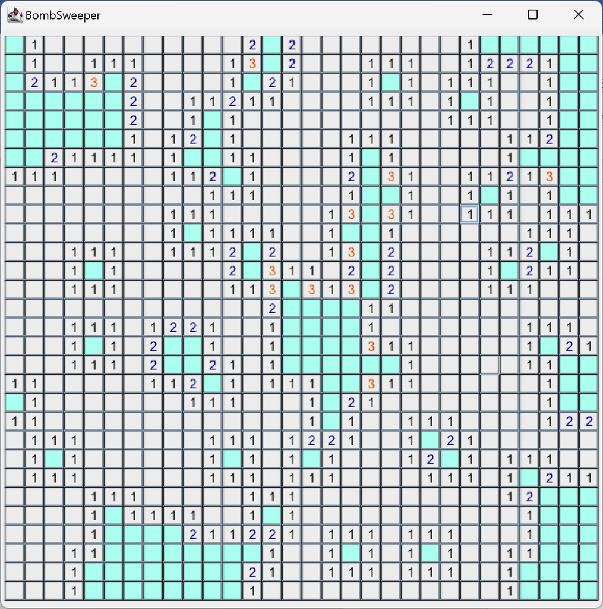

## Task 1: Detecting Bombs

Review the `Javadoc` documentation for the provided classes and study the **BombSquare** source code. Note that the **BombSquare** class is a subclass of **GameSquare**, which also holds application specific information. Note also that in addition to its inherited instance variables, the **BombSquare** class holds information on whether or not a given square contains a bomb. This is generated by a random process in the constructor, such that 1:10 squares contain a bomb.

Based on the resources provided, develop the **BombSquare** class such that when a square is clicked it, it obeys the following rules. **Try to implement this code in as elegant a fashion as you can.**

- Displays an image of a bomb if that square has a bomb on it.
- Displays the number of bombs in surrounding squares otherwise. Note that surrounding squares a classified as the eight squares that are horizontally, vertically or diagonally adjacent to the square.
- Your program must work for a board of *any size* or shape (you can modify this in the main method in the Driver class).

**Hint**: You’ll need to study the methods and instance variables you have inherited from the **GameSquare** class…

## Task 2: Expanding into Empty Space

Traditionally, minesweeper implementations enhance the playing experience by reducing unnecessary work for the player.

*Using recursion*, update your program such that when a square is clicked that has zero bombs in its surrounding squares, it not only reveals that square, but also any adjacent squares (horizontally, vertically or diagonally adjacent).

# Portfolio Contribution

As discussed in the introductory lecture, all practical work this term will contribute to your portfolio assessment **due in week 5**.

This piece of work will carry marks for:

- core functionality related to the accurate implementation of the specification and constrains described above.
- maintaining object-oriented paradigm. Solutions following a procedural/functional paradigm will be significantly penalised.
- scalable and extensible solutions that do not make unnecessary assumptions.